# Kate’s Free Week at Camp: DataCamp, Part 2 Intermediate R | Relational Operators

# 16. Regular Expressions

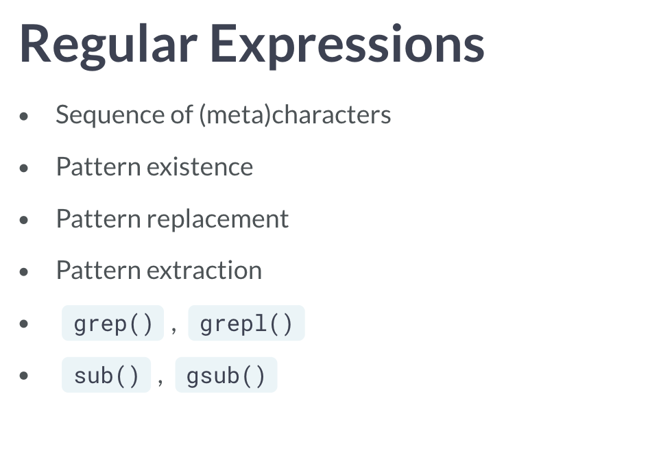

Fun List of Regular Expressions

grepl & grep In their most basic form, regular expressions can be used to see whether a pattern exists inside a character string or a vector of character strings. For this purpose, you can use:

grepl(), which returns TRUE when a pattern is found in the corresponding character string. grep(), which returns a vector of indices of the character strings that contains the pattern.

Both functions need a pattern and an x argument, where pattern is the regular expression you want to match for, and the x argument is the character vector from which matches should be sought.

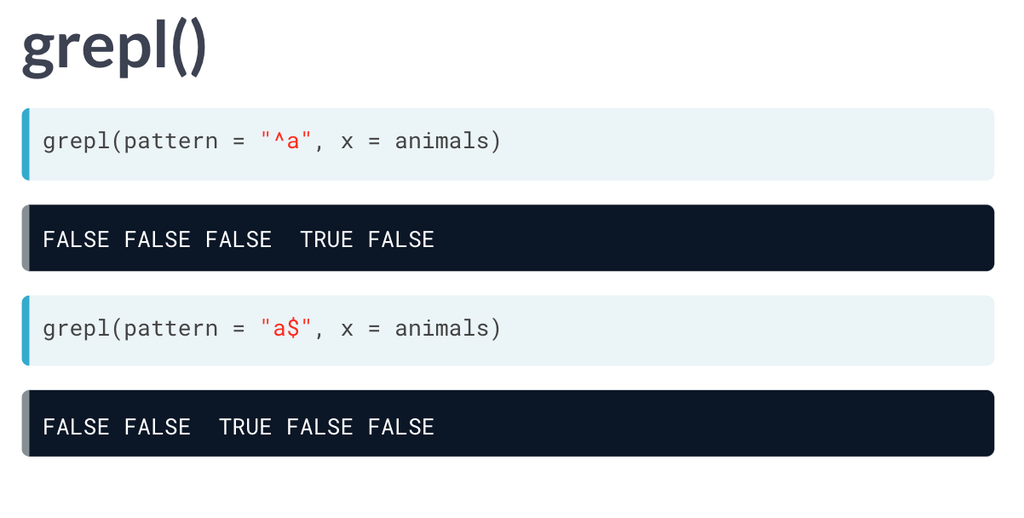

Regular Expressions con’t

Example:

```r
# The emails vector has already been defined for you
emails <- c("john.doe@ivyleague.edu", "education@world.gov", "dalai.lama@peace.org",
            "invalid.edu", "quant@bigdatacollege.edu", "cookie.monster@sesame.tv")

# Use grepl() to match for "edu"
grepl("edu", emails)

# Use grep() to match for "edu", save result to hits
hits <- grep("edu", emails)

# Subset emails using hits
emails[hits]
```

Console Results

```r
# > # The emails vector has already been defined for you
# > emails <- c("john.doe@ivyleague.edu", "education@world.gov", "dalai.lama@peace.org",
#               "invalid.edu", "quant@bigdatacollege.edu", "cookie.monster@sesame.tv")
# >
# > # Use grepl() to match for "edu"
# > grepl("edu", emails)
# [1]  TRUE  TRUE FALSE  TRUE  TRUE FALSE
# >
# > # Use grep() to match for "edu", save result to hits
# > hits <- grep("edu", emails)
# >
# > # Subset emails using hits
# > emails[hits]
# [1] "john.doe@ivyleague.edu"   "education@world.gov"
# [3] "invalid.edu"              "quant@bigdatacollege.edu"
# >
```

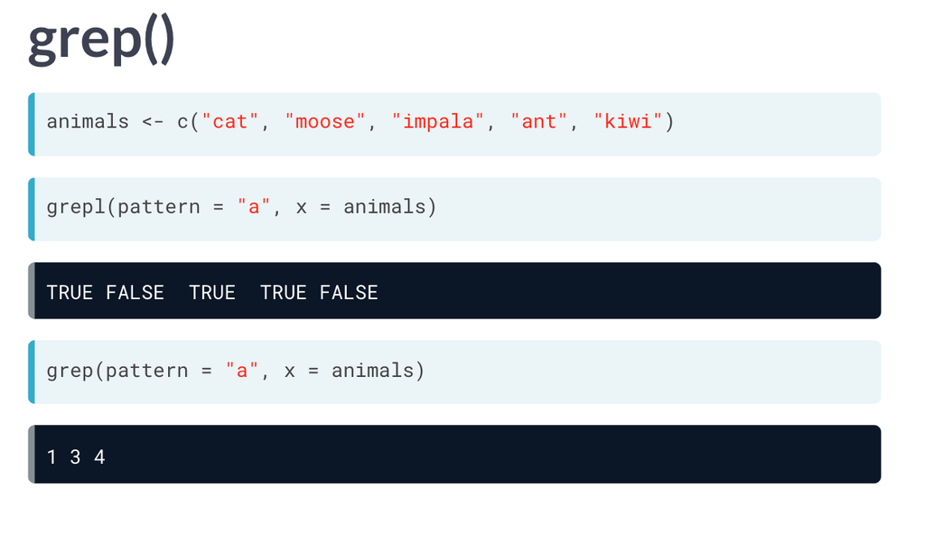

Regular Expressions con’t

sub & gsub While grep() and grepl() were used to simply check whether a regular expression could be matched with a character vector, sub() and gsub() take it one step further: you can specify a replacement argument. If inside the character vector x, the regular expression pattern is found, the matching element(s) will be replaced with replacement.sub() only replaces the first match, whereas gsub() replaces all matches.

example:

```r
# The emails vector has already been defined for you
emails <- c("john.doe@ivyleague.edu", "education@world.gov", "global@peace.org",
            "invalid.edu", "quant@bigdatacollege.edu", "cookie.monster@sesame.tv")

# Use sub() to convert the email domains to datacamp.edu
sub("@.*\\.edu$", "@datacamp.edu", emails)
```

solution from the console:

```r
# > # The emails vector has already been defined for you
# > emails <- c("john.doe@ivyleague.edu", "education@world.gov", "global@peace.org",
#               "invalid.edu", "quant@bigdatacollege.edu", "cookie.monster@sesame.tv")
# >
# > # Use sub() to convert the email domains to datacamp.edu
# > sub("@.*\\.edu$", "@datacamp.edu", emails)
# [1] "john.doe@datacamp.edu"    "education@world.gov"
# [3] "global@peace.org"         "invalid.edu"
# [5] "quant@datacamp.edu"       "cookie.monster@sesame.tv"
```

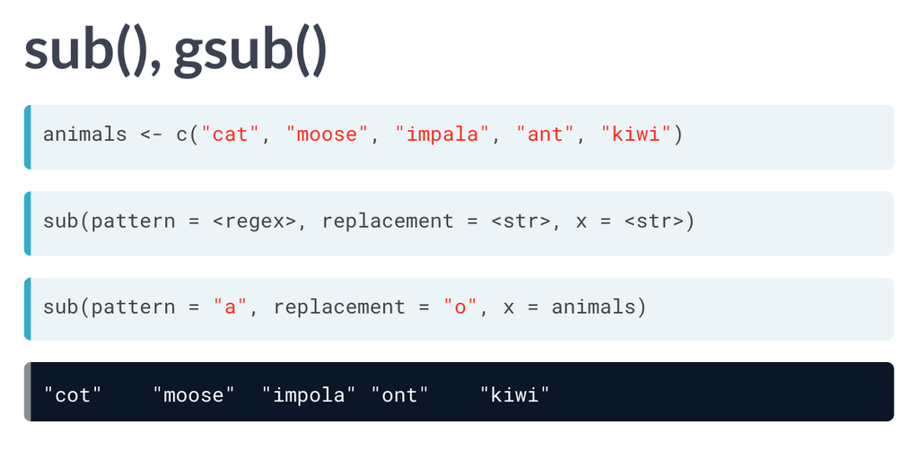

Regular Expressions con’t

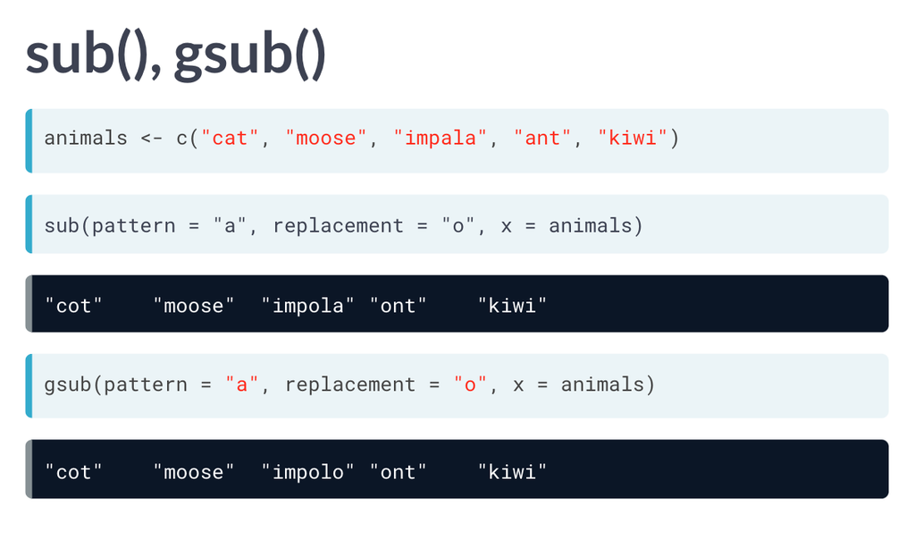

Regular Expressions con’t

# 17. Date Time Objects

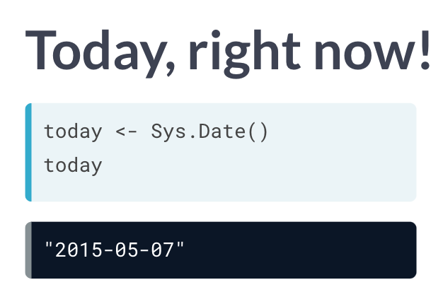

Date Time Objects images

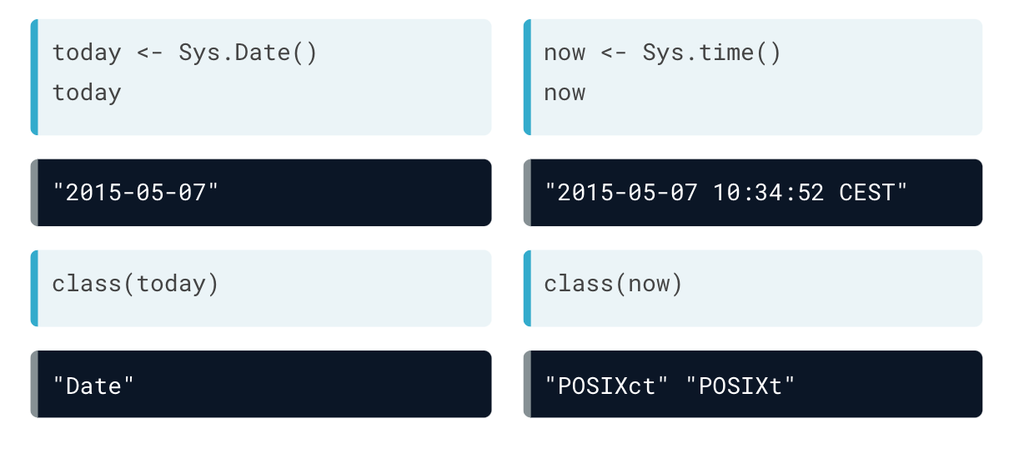

Date Time Objects images

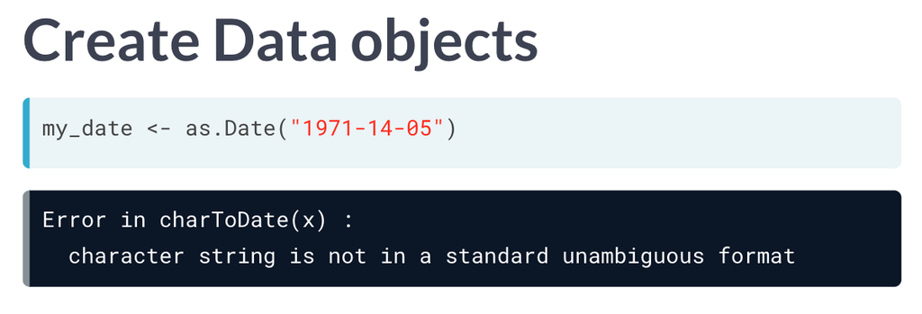

Date Time Objects images

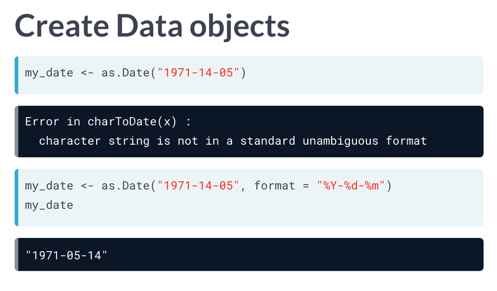

Date Time Objects images

example:

```r
# Get the current date: today
today <- Sys.Date()

# See what today looks like under the hood
unclass(today)

# Get the current time: now
now <- Sys.time()

# See what now looks like under the hood
unclass(now)
```

Solution from the console view

```r
# > # Get the current date: today
# > today <- Sys.Date()
# >
# > # See what today looks like under the hood
# > unclass(today)
# [1] 18403
# >
# > # Get the current time: now
# > now <- Sys.time()
# >
# > # See what now looks like under the hood
# > unclass(now)
# [1] 1590084898
```

## 17.1 Create and format dates

To create a Date object from a simple character string in R, you can use the as.Date() function. The character string has to obey a format that can be defined using a set of symbols (the examples correspond to 13 January, 1982):

%Y: 4-digit year (1982) %y: 2-digit year (82) %m: 2-digit month (01) %d: 2-digit day of the month (13) %A: weekday (Wednesday) %a: abbreviated weekday (Wed) %B: month (January) %b: abbreviated month (Jan) The following R commands will all create the same Date object for the 13th day in January of 1982:

as.Date(“1982-01-13”) as.Date(“Jan-13-82”, format = “%b-%d-%y”) as.Date(“13 January, 1982”, format = “%d %B, %Y”)